# 심혈관 질환 환자 예측 보고서

### 1. 요약(초록)

심혈관 질환을 과연 예측할 수 있을까?라는 질문에서부터 시작한 이번 분석은 Cardiovascular Disease dataset을 바탕으로 진행하였다.

### 2. 분석 주제

Cardiovascular Disease dataset를 이용하여, 심혈관 환자를 가장 잘 예측해주는 모델을 찾는다.

### 3. 데이터 선정

데이터는 Cardiovascular Disease dataset을 사용하였다. 출처 : Kaggle (https://www.kaggle.com/sulianova/cardiovascular-disease-dataset)

특성 : 7만명의 환자들의 검사 결과를 통해 데이터를 수집하였기에 머신러닝 모델을 만들기에 적합하다. 변수 : age, height, weight, gender, ap_hi(systolic blood pressure), ap_lo(Diastolic blood pressure), cholesterol, gluc(glucose), smoke, alco(alchol intake), active(physical activity), cardio(prescence or absence of cardiovascular disease)

### 4-1. 모델링 준비하기

#### 분석 목적 및 방법

원본데이터의 id를 제외한 변수들을 가지고 분석하여 모델을 4개를 만들고, 모델들의 성능평가를 통해 최종적으로 성능이 가장 좋은 모델을 선택한다.

##### 1) 분석 전 패키지 불러오기

```r
library(tidymodels)
library(dplyr)
library(ggplot2)
library(readr)
```

##### 2) 데이터 로드 및 복제

```r
disease_raw <- read_delim("cardiovascular_disease_dataset.csv", delim = ";")

df <- disease_raw
```

##### 3) 데이터 탐색 및 전처리

```r
# 데이터 탐색
glimpse(df)
```

```
## Rows: 70,000
## Columns: 13
## $ id          <dbl> 0, 1, 2, 3, 4, 8, 9, 12, 13, 14, 15, 16, 18, 21, 23, 24, 2~
## $ age         <dbl> 18393, 20228, 18857, 17623, 17474, 21914, 22113, 22584, 17~
## $ gender      <dbl> 2, 1, 1, 2, 1, 1, 1, 2, 1, 1, 1, 2, 2, 1, 2, 2, 1, 1, 1, 2~
## $ height      <dbl> 168, 156, 165, 169, 156, 151, 157, 178, 158, 164, 169, 173~
## $ weight      <dbl> 62, 85, 64, 82, 56, 67, 93, 95, 71, 68, 80, 60, 60, 78, 95~
## $ ap_hi       <dbl> 110, 140, 130, 150, 100, 120, 130, 130, 110, 110, 120, 120~
## $ ap_lo       <dbl> 80, 90, 70, 100, 60, 80, 80, 90, 70, 60, 80, 80, 80, 70, 9~
## $ cholesterol <dbl> 1, 3, 3, 1, 1, 2, 3, 3, 1, 1, 1, 1, 1, 1, 1, 1, 1, 1, 1, 1~
## $ gluc        <dbl> 1, 1, 1, 1, 1, 2, 1, 3, 1, 1, 1, 1, 1, 1, 1, 1, 1, 3, 1, 1~
## $ smoke       <dbl> 0, 0, 0, 0, 0, 0, 0, 0, 0, 0, 0, 0, 0, 0, 1, 0, 0, 0, 0, 1~
## $ alco        <dbl> 0, 0, 0, 0, 0, 0, 0, 0, 0, 0, 0, 0, 0, 0, 1, 0, 0, 0, 0, 0~
## $ active      <dbl> 1, 1, 0, 1, 0, 0, 1, 1, 1, 0, 1, 1, 0, 1, 1, 0, 0, 1, 0, 1~
## $ cardio      <dbl> 0, 1, 1, 1, 0, 0, 0, 1, 0, 0, 0, 0, 0, 0, 0, 1, 0, 0, 0, 0~
```

```r
head(df)
```

```
## # A tibble: 6 x 13
##      id   age gender height weight ap_hi ap_lo cholesterol  gluc smoke  alco
##   <dbl> <dbl>  <dbl>  <dbl>  <dbl> <dbl> <dbl>       <dbl> <dbl> <dbl> <dbl>
## 1     0 18393      2    168     62   110    80           1     1     0     0
## 2     1 20228      1    156     85   140    90           3     1     0     0
## 3     2 18857      1    165     64   130    70           3     1     0     0
## 4     3 17623      2    169     82   150   100           1     1     0     0
## 5     4 17474      1    156     56   100    60           1     1     0     0
## 6     8 21914      1    151     67   120    80           2     2     0     0
## # ... with 2 more variables: active <dbl>, cardio <dbl>
```

```r
tail(df)
```

```
## # A tibble: 6 x 13
##      id   age gender height weight ap_hi ap_lo cholesterol  gluc smoke  alco
##   <dbl> <dbl>  <dbl>  <dbl>  <dbl> <dbl> <dbl>       <dbl> <dbl> <dbl> <dbl>
## 1 99992 21074      1    165     80   150    80           1     1     0     0
## 2 99993 19240      2    168     76   120    80           1     1     1     0
## 3 99995 22601      1    158    126   140    90           2     2     0     0
## 4 99996 19066      2    183    105   180    90           3     1     0     1
## 5 99998 22431      1    163     72   135    80           1     2     0     0
## 6 99999 20540      1    170     72   120    80           2     1     0     0
## # ... with 2 more variables: active <dbl>, cardio <dbl>
```

```r
dim(df)
```

```
## [1] 70000    13
```

```r
summary(df)
```

```
##        id             age            gender         height
##  Min.   :    0   Min.   :10798   Min.   :1.00   Min.   : 55.0
##  1st Qu.:25007   1st Qu.:17664   1st Qu.:1.00   1st Qu.:159.0
##  Median :50002   Median :19703   Median :1.00   Median :165.0
##  Mean   :49972   Mean   :19469   Mean   :1.35   Mean   :164.4
##  3rd Qu.:74889   3rd Qu.:21327   3rd Qu.:2.00   3rd Qu.:170.0
##  Max.   :99999   Max.   :23713   Max.   :2.00   Max.   :250.0
##      weight           ap_hi             ap_lo           cholesterol
##  Min.   : 10.00   Min.   : -150.0   Min.   :  -70.00   Min.   :1.000
##  1st Qu.: 65.00   1st Qu.:  120.0   1st Qu.:   80.00   1st Qu.:1.000
##  Median : 72.00   Median :  120.0   Median :   80.00   Median :1.000
##  Mean   : 74.21   Mean   :  128.8   Mean   :   96.63   Mean   :1.367
##  3rd Qu.: 82.00   3rd Qu.:  140.0   3rd Qu.:   90.00   3rd Qu.:2.000
##  Max.   :200.00   Max.   :16020.0   Max.   :11000.00   Max.   :3.000
##       gluc           smoke              alco             active
##  Min.   :1.000   Min.   :0.00000   Min.   :0.00000   Min.   :0.0000
##  1st Qu.:1.000   1st Qu.:0.00000   1st Qu.:0.00000   1st Qu.:1.0000
##  Median :1.000   Median :0.00000   Median :0.00000   Median :1.0000
##  Mean   :1.226   Mean   :0.08813   Mean   :0.05377   Mean   :0.8037
##  3rd Qu.:1.000   3rd Qu.:0.00000   3rd Qu.:0.00000   3rd Qu.:1.0000
##  Max.   :3.000   Max.   :1.00000   Max.   :1.00000   Max.   :1.0000
##      cardio
##  Min.   :0.0000
##  1st Qu.:0.0000
##  Median :0.0000
##  Mean   :0.4997
##  3rd Qu.:1.0000
##  Max.   :1.0000
```

```r
structure(df) # gender, cholesterol, gluc, smoke, alco, active 변수 이상치 없음 확인
```

```
## # A tibble: 70,000 x 13
##       id   age gender height weight ap_hi ap_lo cholesterol  gluc smoke  alco
##    <dbl> <dbl>  <dbl>  <dbl>  <dbl> <dbl> <dbl>       <dbl> <dbl> <dbl> <dbl>
##  1     0 18393      2    168     62   110    80           1     1     0     0
##  2     1 20228      1    156     85   140    90           3     1     0     0
##  3     2 18857      1    165     64   130    70           3     1     0     0
##  4     3 17623      2    169     82   150   100           1     1     0     0
##  5     4 17474      1    156     56   100    60           1     1     0     0
##  6     8 21914      1    151     67   120    80           2     2     0     0
##  7     9 22113      1    157     93   130    80           3     1     0     0
##  8    12 22584      2    178     95   130    90           3     3     0     0
##  9    13 17668      1    158     71   110    70           1     1     0     0
## 10    14 19834      1    164     68   110    60           1     1     0     0
## # ... with 69,990 more rows, and 2 more variables: active <dbl>, cardio <dbl>
```

```r
View(df)
table(is.na(df)) # 결측치 없음 확인
```

```
##
##  FALSE
## 910000
```

```r
# 타겟 변수 검토
df %>%
  count(cardio) %>%
  mutate(ratio = n/sum(n)*100)
```

```
## # A tibble: 2 x 3
##   cardio     n ratio
##    <dbl> <int> <dbl>
## 1      0 35021  50.0
## 2      1 34979  50.0
```

```r
# 50 : 50으로 골고루 있음 확인
class(df$cardio)
```

```
## [1] "numeric"
```

```r
# 타겟변수 전처리
df <- df %>%
  mutate(cardio = ifelse(cardio ==1, "cardio" , "healthy"),
         cardio = factor(cardio, levels = c("cardio","healthy")))

# 타겟변수 순서 확인
df %>%
  count(cardio) %>%
  mutate(ratio = n/sum(n)*100)
```

```
## # A tibble: 2 x 3
##   cardio      n ratio
##   <fct>   <int> <dbl>
## 1 cardio  34979  50.0
## 2 healthy 35021  50.0
```

```r
levels(df$cardio)
```

```
## [1] "cardio"  "healthy"
```

```r
# 타겟변수 제외 변수 탐색 및 전처리
class(df)
```

```
## [1] "spec_tbl_df" "tbl_df"      "tbl"         "data.frame"
```

```r
# age : int(days) 이므로 "n세"로 change
df <- df %>%
  mutate(age = age/365)

table(df$gender)
```

```
##
##     1     2
## 45530 24470
```

```r
#summary(df$gluc)
table(df$cholesterol)
```

```
##
##     1     2     3
## 52385  9549  8066
```

```r
#summary(df$cholesterol)
table(df$gluc)
```

```
##
##     1     2     3
## 59479  5190  5331
```

```r
#summary(df$gluc)
table(df$smoke)
```

```
##
##     0     1
## 63831  6169
```

```r
#summary(df$smoke)
table(df$alco)
```

```
##
##     0     1
## 66236  3764
```

```r
#summary(df$alco)
table(df$active)
```

```
##
##     0     1
## 13739 56261
```

```r
#summary(df$active)
```

### 4.1-1. 모델링 - basic model

##### 1-1) 데이터 분할 및 검토 - Cross validation

```r
# 데이터 분할 (8:2)
set.seed(10)
df_split <- df %>%
  initial_split(prop = 0.8, strata = cardio)
# -> disease와 healthy 50:50으로 나왔으므로
df_split
```

```
## <Analysis/Assess/Total>
## <55999/14001/70000>
```

```r
df_train <- training(df_split)
df_test <- testing(df_split)

#dim(df_train)
#dim(df_test)
#glimpse(df_train)
#glimpse(df_test)

# 비율 비슷한지 확인
df_train %>%
  count(cardio) %>%
  mutate(ratio = n/sum(n))
```

```
## # A tibble: 2 x 3
##   cardio      n ratio
##   <fct>   <int> <dbl>
## 1 cardio  27983 0.500
## 2 healthy 28016 0.500
```

```r
df_test %>%
  count(cardio) %>%
  mutate(ratio = n/sum(n))
```

```
## # A tibble: 2 x 3
##   cardio      n ratio
##   <fct>   <int> <dbl>
## 1 cardio   6996 0.500
## 2 healthy  7005 0.500
```

#### 2) 모델 생성

이 부분 앞까지는 모든 모델에 동일, 이 부분부터 방법론에 따라 모델이 달라지므로 다른 방법 적용해 모델 만들 때 모델링 부분부터 수정!

##### 2-1) 워크플로우 만들기

##### 2-1-1) 레서피(recipe) 생성

- 우선 고유값 많은 변수 중 제외할 데이터를 선택하고, recipe 만들기

```r
library(dlookr)

# 고유값 확률 높은 변수 (기준 0.1)
diagnose(df_train) %>%
  filter(unique_rate > 0.1)
```

```
## # A tibble: 2 x 6
##   variables types   missing_count missing_percent unique_count unique_rate
##   <chr>     <chr>           <int>           <dbl>        <int>       <dbl>
## 1 id        numeric             0               0        55999       1
## 2 age       numeric             0               0         7910       0.141
```

```r
# age는 numeric으로 당연히 고유값 많으므로 변수 포함, id는 제외

stack_recipe <-
  recipe(cardio ~ ., data = df_train) %>%
  update_role(id, new_role = "id")

stack_recipe
```

```
## Data Recipe
##
## Inputs:
##
##       role #variables
##         id          1
##    outcome          1
##  predictor         11
```

##### 2-1-2) 모델 세팅

decision_tree한번 사용하는 모델을 사용

```r
tree_mod <- decision_tree() %>%
  set_engine("rpart") %>%
  set_mode("classification")
```

##### 2-1-3) 워크플로우 생성

recipe, model을 가지고 워크플로우 생성

```r
stack_wf <- workflow() %>%
  add_recipe(stack_recipe) %>%
  add_model(tree_mod)

stack_wf
```

```
## == Workflow ====================================================================
## Preprocessor: Recipe
## Model: decision_tree()
##
## -- Preprocessor ----------------------------------------------------------------
## 0 Recipe Steps
##
## -- Model -----------------------------------------------------------------------
## Decision Tree Model Specification (classification)
##
## Computational engine: rpart
```

##### 2-4) 적합(fit)하여 모델 생성

검증데이터가 아닌, 학습데이터에 fit해야한다. 학습데이터로 모델을 구축하고, 검증데이터로 과적합이 되었는지 최종 성능평가 확인

```r
set.seed(10)
fit_tree <- stack_wf %>%
  fit(data = df_train)
```

##### +) 선택적인 부분

RMarkdown에서 Run할 때 시간을 줄여주기 위해 모델을 RDS로 저장하기 RDS 파일로 저장하고 불러들이면, 모델을 매번 부르는 것보다 시간 절약

```r
saveRDS(fit_tree,"fit_tree.rds")
fit_tree <- readRDS("fit_tree.rds")
# fit_tree에 RDS파일 저장되어 변수처럼 이용 가능
```

##### +) 변수 중요도 그래프로 확인

변수 중요도를 그래프로 확인해봄으로써 추후 중요한 변수를 가지고 파생변수를 만드는데 활용하는 과정 수행 가능

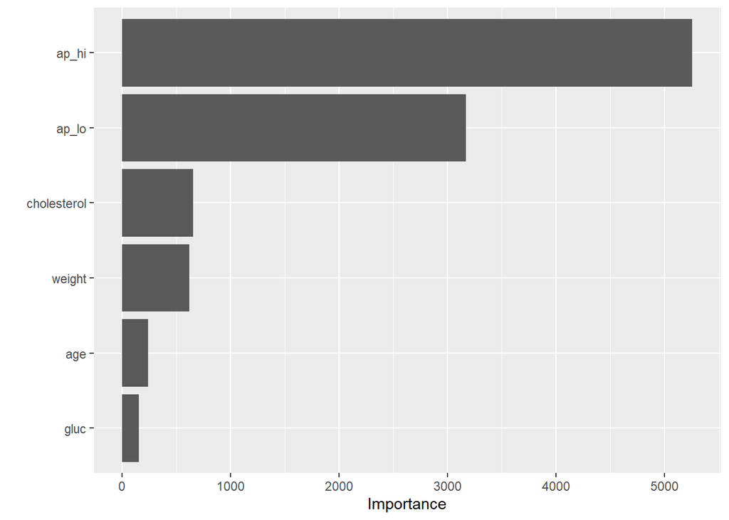

```r
library(vip)
fit_tree %>%
  extract_model() %>%
  vip()
```

##### 2-5) 예측값

train 데이터를 기반으로 한 모델의 예측값을 기존 데이터에 추가 -> 비교할 수 있도록

```r
df_pred_train <- df_train %>%
  bind_cols(predict(fit_tree, df_train)) %>%
  rename(pred = .pred_class)
df_pred_train
```

```
## # A tibble: 55,999 x 14
##       id   age gender height weight ap_hi ap_lo cholesterol  gluc smoke  alco
##    <dbl> <dbl>  <dbl>  <dbl>  <dbl> <dbl> <dbl>       <dbl> <dbl> <dbl> <dbl>
##  1     1  55.4      1    156     85   140    90           3     1     0     0
##  2     2  51.7      1    165     64   130    70           3     1     0     0
##  3     3  48.3      2    169     82   150   100           1     1     0     0
##  4    12  61.9      2    178     95   130    90           3     3     0     0
##  5    32  63.1      1    158     90   145    85           2     2     0     0
##  6    35  45.5      1    170     68   150    90           3     1     0     0
##  7    42  50.1      1    155    105   120    80           3     1     0     0
##  8    43  63.5      1    169     71   140    90           3     1     0     0
##  9    45  56.6      1    160     73   130    85           1     1     0     0
## 10    53  49.7      1    165     70   140    90           1     1     0     0
## # ... with 55,989 more rows, and 3 more variables: active <dbl>, cardio <fct>,
## #   pred <fct>
```

##### 3) 성능평가

학습데이터 성능평가를 하고, 검증데이터 성능평가의 경우에는 지금 하지 않고, 최종적인 모델이 확정되면 그때 검증데이터 성능평가를 하고 지표 확인, 과적합되었는지 확인

```r
# 학습데이터 성능평가
conf_train <- conf_mat(data = df_pred_train,
                       truth = cardio,
                       estimate = pred)
conf_train
```

```
##           Truth
## Prediction cardio healthy
##    cardio   17409    5496
##    healthy  10574   22520
```

```r
summary(conf_train)
```

```
## # A tibble: 13 x 3
##    .metric              .estimator .estimate
##    <chr>                <chr>          <dbl>
##  1 accuracy             binary         0.713
##  2 kap                  binary         0.426
##  3 sens                 binary         0.622
##  4 spec                 binary         0.804
##  5 ppv                  binary         0.760
##  6 npv                  binary         0.680
##  7 mcc                  binary         0.433
##  8 j_index              binary         0.426
##  9 bal_accuracy         binary         0.713
## 10 detection_prevalence binary         0.409
## 11 precision            binary         0.760
## 12 recall               binary         0.622
## 13 f_meas               binary         0.684
```

`accuracy 0.713, precision 0.760, recall = 0.622` ###### 정상인을 심혈관 질환으로 분류하고 지켜보는 것보다 심혈관 질환을 놓치는 경우가 더 심각하므로 recall을 주의깊게 봐야한다고 판단

### 4.1.3 - k-fold 방법 기반 모델 (튜닝 전)

##### 2)모델링

##### 2-1) k-fold 생성

10번의 decision_tree를 만들기 -> 10-folds (보통 10folds를 기본으로 함) 쪼개는건 주사위를 굴리기 때문에 **꼭!** 난수 고정

```r
# library(rsample)
set.seed(10)
folds <- vfold_cv(df_train, v = 10)
folds
```

```
## #  10-fold cross-validation
## # A tibble: 10 x 2
##    splits               id
##    <list>               <chr>
##  1 <split [50399/5600]> Fold01
##  2 <split [50399/5600]> Fold02
##  3 <split [50399/5600]> Fold03
##  4 <split [50399/5600]> Fold04
##  5 <split [50399/5600]> Fold05
##  6 <split [50399/5600]> Fold06
##  7 <split [50399/5600]> Fold07
##  8 <split [50399/5600]> Fold08
##  9 <split [50399/5600]> Fold09
## 10 <split [50400/5599]> Fold10
```

##### 2-2) folds별 모델 생성 및 예측

모델 생성시 난수 고정해주지 않으면 매번 달라질 수 있기 때문에 **꼭!** 난수 고정

```r
set.seed(10)
fit_tree_kfold <-
  stack_wf %>%
  fit_resamples(resamples = folds,
                metrics = metric_set(accuracy, precision, recall, f_meas))
```

##### +) RDS로 저장하기

```r
saveRDS(fit_tree_kfold,"fit_tree_kfold.rds")
fit_tree_kfold <- readRDS("fit_tree_kfold.rds")
```

##### 2-2-1) 개별 fold 살펴보기

fold들 각각의 accuracy, precision, recall, f_meas(f1 score)등의 지표 확인

```r
fit_tree_kfold %>%
  filter(id == "Fold01") %>%
  unnest(.metrics)
```

```
## # A tibble: 4 x 7
##   splits               id     .metric   .estimator .estimate .config    .notes
##   <list>               <chr>  <chr>     <chr>          <dbl> <chr>      <list>
## 1 <split [50399/5600]> Fold01 accuracy  binary         0.721 Preproces~ <tibble~
## 2 <split [50399/5600]> Fold01 precision binary         0.764 Preproces~ <tibble~
## 3 <split [50399/5600]> Fold01 recall    binary         0.633 Preproces~ <tibble~
## 4 <split [50399/5600]> Fold01 f_meas    binary         0.692 Preproces~ <tibble~
```

##### 3) 성능 평가

마찬가지로 학습데이터 성능평가를 시행 검증데이터 성능평가는 추후 이 모델이 최종적으로 확정된 모델일 때 확인

```r
collect_metrics(fit_tree_kfold)
```

```
## # A tibble: 4 x 6
##   .metric   .estimator  mean     n std_err .config
##   <chr>     <chr>      <dbl> <int>   <dbl> <chr>
## 1 accuracy  binary     0.713    10 0.00170 Preprocessor1_Model1
## 2 f_meas    binary     0.684    10 0.00224 Preprocessor1_Model1
## 3 precision binary     0.760    10 0.00203 Preprocessor1_Model1
## 4 recall    binary     0.622    10 0.00308 Preprocessor1_Model1
```

`accuracy는 0.713, precision은 0.760, f_meas는 0.684, recall은 0.622` 개별적인 folds의 평가지표의 평균 basic model의 학습데이터 성능평가 결과와 동일(아래코드)

```r
summary(conf_train) %>%
  slice(1, 13, 11, 12)    # 와 비교
```

```
## # A tibble: 4 x 3
##   .metric   .estimator .estimate
##   <chr>     <chr>          <dbl>
## 1 accuracy  binary         0.713
## 2 f_meas    binary         0.684
## 3 precision binary         0.760
## 4 recall    binary         0.622
```

##### 3-1) k-fold 성능평가 결과 개별적으로 살펴보기

```r
collect_metrics(fit_tree_kfold, summarize = F)
```

```
## # A tibble: 40 x 5
##    id     .metric   .estimator .estimate .config
##    <chr>  <chr>     <chr>          <dbl> <chr>
##  1 Fold01 accuracy  binary         0.721 Preprocessor1_Model1
##  2 Fold01 precision binary         0.764 Preprocessor1_Model1
##  3 Fold01 recall    binary         0.633 Preprocessor1_Model1
##  4 Fold01 f_meas    binary         0.692 Preprocessor1_Model1
##  5 Fold02 accuracy  binary         0.712 Preprocessor1_Model1
##  6 Fold02 precision binary         0.750 Preprocessor1_Model1
##  7 Fold02 recall    binary         0.616 Preprocessor1_Model1
##  8 Fold02 f_meas    binary         0.676 Preprocessor1_Model1
##  9 Fold03 accuracy  binary         0.711 Preprocessor1_Model1
## 10 Fold03 precision binary         0.756 Preprocessor1_Model1
## # ... with 30 more rows
```

### 4.1.4 Tuning(튜닝)과정 후 k-fold 방법 기반 모델

##### 2)모델링

##### 2.1) 하이퍼파라미터 탐색 - K-fold 데이터

###### 2.1-1) K-fold 생성 - 5 folds

```r
set.seed(10)
folds <- vfold_cv(df_train, v = 5)
folds
```

```
## #  5-fold cross-validation
## # A tibble: 5 x 2
##   splits                id
##   <list>                <chr>
## 1 <split [44799/11200]> Fold1
## 2 <split [44799/11200]> Fold2
## 3 <split [44799/11200]> Fold3
## 4 <split [44799/11200]> Fold4
## 5 <split [44800/11199]> Fold5
```

##### 2.1-2) 워크플로우 만들기 - 설계도

###### 레서피 세팅

변수 검토

```r
library(dlookr)
diagnose(df_train) %>%
  filter(unique_rate > 0.1)
```

```
## # A tibble: 2 x 6
##   variables types   missing_count missing_percent unique_count unique_rate
##   <chr>     <chr>           <int>           <dbl>        <int>       <dbl>
## 1 id        numeric             0               0        55999       1
## 2 age       numeric             0               0         7910       0.141
```

`age는 고유값이 많은게 당연, id만 제외`

레시피 생성

```r
stack_recipe <-
  recipe(data = df_train, cardio ~ .) %>%
  update_role(id, new_role = "id")
stack_recipe
```

```
## Data Recipe
##
## Inputs:
##
##       role #variables
##         id          1
##    outcome          1
##  predictor         11
```

###### 모델 세팅

튜닝할 하이퍼 파라미터 설정 - cost complexity : 비용 복잡도 (끝 노드의 개수) - tree_depth : 나무 깊이

```r
tree_spec <- decision_tree(cost_complexity = tune(),
                           tree_depth = tune()) %>%
  set_engine("rpart") %>%
  set_mode("classification")

tree_spec
```

```
## Decision Tree Model Specification (classification)
##
## Main Arguments:
##   cost_complexity = tune()
##   tree_depth = tune()
##
## Computational engine: rpart
```

###### 워크플로우 생성

```r
stack_wf_tune <- workflow() %>%
  add_recipe(stack_recipe) %>%
  add_model(tree_spec)

stack_wf_tune
```

```
## == Workflow ====================================================================
## Preprocessor: Recipe
## Model: decision_tree()
##
## -- Preprocessor ----------------------------------------------------------------
## 0 Recipe Steps
##
## -- Model -----------------------------------------------------------------------
## Decision Tree Model Specification (classification)
##
## Main Arguments:
##   cost_complexity = tune()
##   tree_depth = tune()
##
## Computational engine: rpart
```

###### tune grid 생성

다양한 하이퍼파라미터(사용자가 지정) 생성 -> 5*5 = 25세트

```r
tree_grid <- grid_regular(cost_complexity(),   # 비용 복잡도
                          tree_depth(),  # 나무 깊이
                          levels = 5)
tree_grid
```

```
## # A tibble: 25 x 2
##    cost_complexity tree_depth
##              <dbl>      <int>
##  1    0.0000000001          1
##  2    0.0000000178          1
##  3    0.00000316            1
##  4    0.000562              1
##  5    0.1                   1
##  6    0.0000000001          4
##  7    0.0000000178          4
##  8    0.00000316            4
##  9    0.000562              4
## 10    0.1                   4
## # ... with 15 more rows
```

##### 2.1.3) 모델 생성 및 예측

각 fold에 tree_grid 적용 모델 생성, 예측 -> fold(5) * grid(25) = 125모델

```r
library(tune)
set.seed(10)
fit_tree_tune <- stack_wf_tune %>%
  tune_grid(resamples = folds,
            grid = tree_grid,
            metrics = metric_set(accuracy, precision, recall, f_meas, roc_auc))
```

+) RDS파일에 저장 후 변수처럼 이용

```r
saveRDS(fit_tree_tune, "fit_tree_tune.rds")
fit_tree_tune <- readRDS("fit_tree_tune.rds")
```

##### 2.1.4) 성능 평가 및 하이퍼파라미터 탐색

개별 Fold 살펴보기 -> grid(25) * metrics(5) = 125개 성능 지표

```r
#library(tidyr)
fit_tree_tune %>%
  filter(id == "Fold1") %>%
  unnest(.metrics)
```

```
## # A tibble: 125 x 9
##    splits  id    cost_complexity tree_depth .metric .estimator .estimate .config
##    <list>  <chr>           <dbl>      <int> <chr>   <chr>          <dbl> <chr>
##  1 <split~ Fold1    0.0000000001          1 accura~ binary         0.715 Prepro~
##  2 <split~ Fold1    0.0000000001          1 precis~ binary         0.761 Prepro~
##  3 <split~ Fold1    0.0000000001          1 recall  binary         0.623 Prepro~
##  4 <split~ Fold1    0.0000000001          1 f_meas  binary         0.685 Prepro~
##  5 <split~ Fold1    0.0000000001          1 roc_auc binary         0.714 Prepro~
##  6 <split~ Fold1    0.0000000178          1 accura~ binary         0.715 Prepro~
##  7 <split~ Fold1    0.0000000178          1 precis~ binary         0.761 Prepro~
##  8 <split~ Fold1    0.0000000178          1 recall  binary         0.623 Prepro~
##  9 <split~ Fold1    0.0000000178          1 f_meas  binary         0.685 Prepro~
## 10 <split~ Fold1    0.0000000178          1 roc_auc binary         0.714 Prepro~
## # ... with 115 more rows, and 1 more variable: .notes <list>
```

하이퍼파라미터 살펴보기 - folds 평균

```r
fit_tree_tune %>%
  collect_metrics()
```

```
## # A tibble: 125 x 8
##    cost_complexity tree_depth .metric   .estimator  mean     n  std_err .config
##              <dbl>      <int> <chr>     <chr>      <dbl> <int>    <dbl> <chr>
##  1    0.0000000001          1 accuracy  binary     0.713     5 0.00115  Preproc~
##  2    0.0000000001          1 f_meas    binary     0.684     5 0.00144  Preproc~
##  3    0.0000000001          1 precision binary     0.760     5 0.00165  Preproc~
##  4    0.0000000001          1 recall    binary     0.622     5 0.00133  Preproc~
##  5    0.0000000001          1 roc_auc   binary     0.713     5 0.000823 Preproc~
##  6    0.0000000178          1 accuracy  binary     0.713     5 0.00115  Preproc~
##  7    0.0000000178          1 f_meas    binary     0.684     5 0.00144  Preproc~
##  8    0.0000000178          1 precision binary     0.760     5 0.00165  Preproc~
##  9    0.0000000178          1 recall    binary     0.622     5 0.00133  Preproc~
## 10    0.0000000178          1 roc_auc   binary     0.713     5 0.000823 Preproc~
## # ... with 115 more rows
```

지표 가장 높은 후보

```r
fit_tree_tune %>%
  show_best("precision")
```

```
## # A tibble: 5 x 8
##   cost_complexity tree_depth .metric   .estimator  mean     n std_err .config
##             <dbl>      <int> <chr>     <chr>      <dbl> <int>   <dbl> <chr>
## 1    0.0000000001          1 precision binary     0.760     5 0.00165 Preproces~
## 2    0.0000000178          1 precision binary     0.760     5 0.00165 Preproces~
## 3    0.00000316            1 precision binary     0.760     5 0.00165 Preproces~
## 4    0.000562              1 precision binary     0.760     5 0.00165 Preproces~
## 5    0.1                   1 precision binary     0.760     5 0.00165 Preproces~
```

```r
fit_tree_tune %>%
  show_best("accuracy")
```

```
## # A tibble: 5 x 8
##   cost_complexity tree_depth .metric  .estimator  mean     n  std_err .config
##             <dbl>      <int> <chr>    <chr>      <dbl> <int>    <dbl> <chr>
## 1    0.000562              8 accuracy binary     0.732     5 0.000741 Preproces~
## 2    0.000562             11 accuracy binary     0.731     5 0.000802 Preproces~
## 3    0.000562             15 accuracy binary     0.731     5 0.000802 Preproces~
## 4    0.0000000001          8 accuracy binary     0.729     5 0.00121  Preproces~
## 5    0.0000000178          8 accuracy binary     0.729     5 0.00121  Preproces~
```

```r
fit_tree_tune %>%
  show_best("roc_auc")
```

```
## # A tibble: 5 x 8
##   cost_complexity tree_depth .metric .estimator  mean     n  std_err .config
##             <dbl>      <int> <chr>   <chr>      <dbl> <int>    <dbl> <chr>
## 1    0.0000000001          8 roc_auc binary     0.791     5 0.000993 Preprocess~
## 2    0.0000000178          8 roc_auc binary     0.791     5 0.000993 Preprocess~
## 3    0.00000316            8 roc_auc binary     0.791     5 0.000993 Preprocess~
## 4    0.0000000001         11 roc_auc binary     0.785     5 0.00206  Preprocess~
## 5    0.0000000178         11 roc_auc binary     0.785     5 0.00206  Preprocess~
```

###### 최적 선택

성능 지표 최고 중 cost_complexity, tree_depth 최저 -> 평가 지표가 높은 것 중 tree_depth와 cost_complexity가 낮은 값을 찾는 것 -> 즉 성능평가 결과는 좋은데 굳이 복잡할 필요 없기에 단순화된 모델을 위한 하이퍼파라미터 값 찾기

```r
best_tree <- fit_tree_tune %>%
  select_best("roc_auc")
best_tree
```

```
## # A tibble: 1 x 3
##   cost_complexity tree_depth .config
##             <dbl>      <int> <chr>
## 1    0.0000000001          8 Preprocessor1_Model11
```

`cost_complexity가 0.0000000001, tree_dept = 8 인게 성능 지표 최고 중 단순한 모델을 위한 하이퍼파라미터 값`

##### 2.2) 최종 모델 생성 - training 데이터

##### 2.2-1) 기존 워크플로우(stack_wf_tune) 업데이트

```r
# 현재 워크플로우
stack_wf_tune
```

```
## == Workflow ====================================================================
## Preprocessor: Recipe
## Model: decision_tree()
##
## -- Preprocessor ----------------------------------------------------------------
## 0 Recipe Steps
##
## -- Model -----------------------------------------------------------------------
## Decision Tree Model Specification (classification)
##
## Main Arguments:
##   cost_complexity = tune()
##   tree_depth = tune()
##
## Computational engine: rpart
```

```r
# 업데이트
# library(tune)
final_wf <- stack_wf_tune %>%
  finalize_workflow(best_tree)
final_wf
```

```
## == Workflow ====================================================================
## Preprocessor: Recipe
## Model: decision_tree()
##
## -- Preprocessor ----------------------------------------------------------------
## 0 Recipe Steps
##
## -- Model -----------------------------------------------------------------------
## Decision Tree Model Specification (classification)
##
## Main Arguments:
##   cost_complexity = 1e-10
##   tree_depth = 8
##
## Computational engine: rpart
```

##### 2.2-2) 최종 모델 생성

```r
set.seed(10)
fit_tree_tune_final <- final_wf %>%
  fit(data = df_train)

fit_tree_tune_final
```

```
## == Workflow [trained] ==========================================================
## Preprocessor: Recipe
## Model: decision_tree()
##
## -- Preprocessor ----------------------------------------------------------------
## 0 Recipe Steps
##
## -- Model -----------------------------------------------------------------------
## n= 55999
##
## node), split, n, loss, yval, (yprob)
##       * denotes terminal node
##
##   1) root 55999 27983 healthy (0.49970535 0.50029465)
##     2) ap_hi>=129.5 22905  5496 cardio (0.76005239 0.23994761)
##       4) ap_hi>=138.5 15493  2515 cardio (0.83766862 0.16233138)
##         8) ap_hi>=149.5 7621  1077 cardio (0.85867996 0.14132004)
##          16) ap_lo>=68.5 7543  1046 cardio (0.86132838 0.13867162)
##            32) weight>=51.5 7439  1018 cardio (0.86315365 0.13684635) *
##            33) weight< 51.5 104    28 cardio (0.73076923 0.26923077)
##              66) active>=0.5 83    18 cardio (0.78313253 0.21686747) *
##              67) active< 0.5 21    10 cardio (0.52380952 0.47619048)
##               134) weight< 48.5 7     1 cardio (0.85714286 0.14285714) *
##               135) weight>=48.5 14     5 healthy (0.35714286 0.64285714) *
##          17) ap_lo< 68.5 78    31 cardio (0.60256410 0.39743590)
##            34) ap_hi< 252 67    21 cardio (0.68656716 0.31343284)
##              68) ap_lo< 62 59    16 cardio (0.72881356 0.27118644) *
##              69) ap_lo>=62 8     3 healthy (0.37500000 0.62500000) *
##            35) ap_hi>=252 11     1 healthy (0.09090909 0.90909091) *
##         9) ap_hi< 149.5 7872  1438 cardio (0.81732724 0.18267276)
##          18) gluc< 2.5 7041  1244 cardio (0.82332055 0.17667945)
##            36) ap_hi< 145.5 7004  1229 cardio (0.82452884 0.17547116)
##              72) height>=147.5 6906  1199 cardio (0.82638286 0.17361714) *
##              73) height< 147.5 98    30 cardio (0.69387755 0.30612245)
##               146) age< 61.9 74    17 cardio (0.77027027 0.22972973) *
##               147) age>=61.9 24    11 healthy (0.45833333 0.54166667)
##                 294) ap_lo>=82.5 15     5 cardio (0.66666667 0.33333333) *
##                 295) ap_lo< 82.5 9     1 healthy (0.11111111 0.88888889) *
##            37) ap_hi>=145.5 37    15 cardio (0.59459459 0.40540541)
##              74) height>=160.5 28     9 cardio (0.67857143 0.32142857) *
##              75) height< 160.5 9     3 healthy (0.33333333 0.66666667) *
##          19) gluc>=2.5 831   194 cardio (0.76654633 0.23345367)
##            38) weight< 78.5 412    78 cardio (0.81067961 0.18932039)
##              76) age>=42.17945 404    73 cardio (0.81930693 0.18069307) *
##              77) age< 42.17945 8     3 healthy (0.37500000 0.62500000) *
##            39) weight>=78.5 419   116 cardio (0.72315036 0.27684964)
##              78) cholesterol>=1.5 342    83 cardio (0.75730994 0.24269006) *
##              79) cholesterol< 1.5 77    33 cardio (0.57142857 0.42857143)
##               158) weight< 81.5 13     2 cardio (0.84615385 0.15384615) *
##               159) weight>=81.5 64    31 cardio (0.51562500 0.48437500)
##                 318) weight>=84.5 53    22 cardio (0.58490566 0.41509434) *
##                 319) weight< 84.5 11     2 healthy (0.18181818 0.81818182) *
##       5) ap_hi< 138.5 7412  2981 cardio (0.59781436 0.40218564)
##        10) cholesterol>=2.5 1379   276 cardio (0.79985497 0.20014503)
##          20) gluc< 2.5 835   143 cardio (0.82874251 0.17125749) *
##          21) gluc>=2.5 544   133 cardio (0.75551471 0.24448529)
##            42) height< 180.5 529   124 cardio (0.76559546 0.23440454) *
##            43) height>=180.5 15     6 healthy (0.40000000 0.60000000) *
##
## ...
## and 172 more lines.
```

#### 3. 모델 활용 - training 데이터

k-fold 모델에 대입 folds별 모델 생성 및 예측

```r
set.seed(10)
fit_tree_tune_kfold <-
  fit_tree_tune_final %>%
  fit_resamples(resamples = folds,
                metrics = metric_set(accuracy, precision, recall, f_meas))

fit_tree_tune_kfold
```

```
## # Resampling results
## # 5-fold cross-validation
## # A tibble: 5 x 4
##   splits                id    .metrics         .notes
##   <list>                <chr> <list>           <list>
## 1 <split [44799/11200]> Fold1 <tibble [4 x 4]> <tibble [0 x 1]>
## 2 <split [44799/11200]> Fold2 <tibble [4 x 4]> <tibble [0 x 1]>
## 3 <split [44799/11200]> Fold3 <tibble [4 x 4]> <tibble [0 x 1]>
## 4 <split [44799/11200]> Fold4 <tibble [4 x 4]> <tibble [0 x 1]>
## 5 <split [44800/11199]> Fold5 <tibble [4 x 4]> <tibble [0 x 1]>
```

```r
fit_tree_tune_kfold %>%
  filter(id == "Fold01") %>%
  unnest(.metrics)
```

```
## # A tibble: 0 x 4
## # ... with 4 variables: splits <list>, id <chr>, .metrics <???>, .notes <list>
```

##### 성능 평가 - 학습데이터

```r
collect_metrics(fit_tree_tune_kfold)
```

```
## # A tibble: 4 x 6
##   .metric   .estimator  mean     n std_err .config
##   <chr>     <chr>      <dbl> <int>   <dbl> <chr>
## 1 accuracy  binary     0.729     5 0.00121 Preprocessor1_Model1
## 2 f_meas    binary     0.715     5 0.00290 Preprocessor1_Model1
## 3 precision binary     0.753     5 0.00433 Preprocessor1_Model1
## 4 recall    binary     0.680     5 0.00618 Preprocessor1_Model1
```

`accuracy는 0.729, precision은 0.753, recall은 0.680, f_meas는 0.715` ###### 다른 방법의 성능 지표와 비교

```r
# 튜닝전의 k-fold모델과 비교(학습데이터 성능평가)
collect_metrics(fit_tree_kfold)
```

```
## # A tibble: 4 x 6
##   .metric   .estimator  mean     n std_err .config
##   <chr>     <chr>      <dbl> <int>   <dbl> <chr>
## 1 accuracy  binary     0.713    10 0.00170 Preprocessor1_Model1
## 2 f_meas    binary     0.684    10 0.00224 Preprocessor1_Model1
## 3 precision binary     0.760    10 0.00203 Preprocessor1_Model1
## 4 recall    binary     0.622    10 0.00308 Preprocessor1_Model1
```

```r
# basic 모델과 비교(학습데이터 성능평가)
summary(conf_train) %>%
  slice(1, 13, 11, 12)
```

```
## # A tibble: 4 x 3
##   .metric   .estimator .estimate
##   <chr>     <chr>          <dbl>
## 1 accuracy  binary         0.713
## 2 f_meas    binary         0.684
## 3 precision binary         0.760
## 4 recall    binary         0.622
```

둘다 `0.713, 0.760,0.622,0.684`

결과적으로, **튜닝했을 때의 결과, 더 성능이 높다고 할 수 있음.**

###### 다른 모델과 시각화 통해 비교

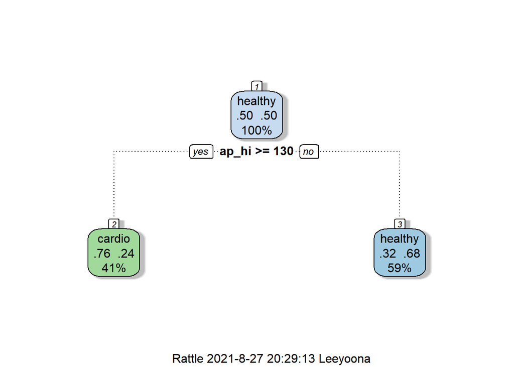

```r
library(rattle)
# basic model
fit_tree %>%
  extract_model() %>%
  fancyRpartPlot()
```

[figure not shown]

```r
# tuning
fit_tree_tune_final %>%
  extract_model() %>%
  fancyRpartPlot()
```

###### k-fold 성능평가 결과 개별적으로 살펴보기

```r
tail(collect_metrics(fit_tree_kfold, summarize = F))
```

```
## # A tibble: 6 x 5
##   id     .metric   .estimator .estimate .config
##   <chr>  <chr>     <chr>          <dbl> <chr>
## 1 Fold09 recall    binary         0.636 Preprocessor1_Model1
## 2 Fold09 f_meas    binary         0.693 Preprocessor1_Model1
## 3 Fold10 accuracy  binary         0.718 Preprocessor1_Model1
## 4 Fold10 precision binary         0.756 Preprocessor1_Model1
## 5 Fold10 recall    binary         0.626 Preprocessor1_Model1
## 6 Fold10 f_meas    binary         0.685 Preprocessor1_Model1
```

###### +) 추가적으로 만약 tuning한 결과가 최종 모델이라면? -> 예측성능 -test 데이터

뒤에 나오는 random forest 모델이 더 학습데이터에 대한 성능이 높게 나오기 때문에 randomforest에 대한 검증데이터 성능평가를 해야함. 그래서 이 코드는 참고만 하자.

```r
# 1. 예측
df_pred_test_tune_final <- df_test %>%
  bind_cols(predict(fit_tree_tune_final, df_test)) %>%
  rename(pred = .pred_class)

# 2. 성능평가
conf_test_tune_final <- conf_mat(data = df_pred_test_tune_final, truth = cardio,
                                 estimate = pred)
summary(conf_test_tune_final) %>%
  slice(1,11,12,13) %>%
  select(1,3)
```

```
## # A tibble: 4 x 2
##   .metric   .estimate
##   <chr>         <dbl>
## 1 accuracy      0.734
## 2 precision     0.741
## 3 recall        0.719
## 4 f_meas        0.730
```

### 4.1.5 randomforest 방법 기반 모델

```r
recipe_rf <-
  recipe(data = df, cardio ~ .) %>%
  update_role(id,new_role = "id") %>%
  step_knnimpute(all_predictors())
```

##### 모델 세팅

```r
tree_mod_rf <- rand_forest() %>%
  set_engine("ranger", importance = "impurity") %>%
  set_mode("classification")
```

##### 워크플로우 생성

```r
stack_wf_rf <- workflow() %>%
  add_recipe(recipe_rf) %>%
  add_model(tree_mod_rf)
```

##### 모델 생성

```r
set.seed(10)
#fit_tree_rf <- stack_wf_rf %>%
#  fit(data = df)
# 주석처리한 코드는 교재에 있는대로, train, test 나누지 않은 경우

# 아래는 train, test로 나눈 경우
fit_tree_rf <- stack_wf_rf %>%
  fit(data = df_train)
```

##### +) RDS로 모델 저장

```r
saveRDS(fit_tree_rf, "fit_tree_rf.rds")
fit_tree_rf <- readRDS("fit_tree_rf.rds")
```

##### 예측

사실 이부분부터 바로 아래 성능평가까지는 train데이터, test데이터를 나눈 것을 각각 해야한다고 생각해 project.R에는 그렇게 코드를 짰는데 강사님 Machine Learning실습 교재에서는 안나누고 하셔서 일단 따라함. project.R코드에서는 나눠서 한 것 나와있음!

```r
# train, test 나누지 않은 경우. 즉 위의 코드처럼 data = df한 경우인데
# 이렇게 나누지 않고 하고자 하는 경우, 위 코드에서 주석 처리한 data = df 코드 실행하고 data = df_train 코드 실행은 x하기!
df_pred_rf <- df %>%
  bind_cols(predict(fit_tree_rf, df)) %>%
  rename(pred = .pred_class)
df_pred_rf
```

```
## # A tibble: 70,000 x 14
##       id   age gender height weight ap_hi ap_lo cholesterol  gluc smoke  alco
##    <dbl> <dbl>  <dbl>  <dbl>  <dbl> <dbl> <dbl>       <dbl> <dbl> <dbl> <dbl>
##  1     0  50.4      2    168     62   110    80           1     1     0     0
##  2     1  55.4      1    156     85   140    90           3     1     0     0
##  3     2  51.7      1    165     64   130    70           3     1     0     0
##  4     3  48.3      2    169     82   150   100           1     1     0     0
##  5     4  47.9      1    156     56   100    60           1     1     0     0
##  6     8  60.0      1    151     67   120    80           2     2     0     0
##  7     9  60.6      1    157     93   130    80           3     1     0     0
##  8    12  61.9      2    178     95   130    90           3     3     0     0
##  9    13  48.4      1    158     71   110    70           1     1     0     0
## 10    14  54.3      1    164     68   110    60           1     1     0     0
## # ... with 69,990 more rows, and 3 more variables: active <dbl>, cardio <fct>,
## #   pred <fct>
```

```r
# 예측값(train 데이터 기반) 추가
df_pred_train_rf <- df_train %>%
  bind_cols(predict(fit_tree_rf, df_train)) %>%
  rename(pred = .pred_class)
df_pred_train_rf
```

```
## # A tibble: 55,999 x 14
##       id   age gender height weight ap_hi ap_lo cholesterol  gluc smoke  alco
##    <dbl> <dbl>  <dbl>  <dbl>  <dbl> <dbl> <dbl>       <dbl> <dbl> <dbl> <dbl>
##  1     1  55.4      1    156     85   140    90           3     1     0     0
##  2     2  51.7      1    165     64   130    70           3     1     0     0
##  3     3  48.3      2    169     82   150   100           1     1     0     0
##  4    12  61.9      2    178     95   130    90           3     3     0     0
##  5    32  63.1      1    158     90   145    85           2     2     0     0
##  6    35  45.5      1    170     68   150    90           3     1     0     0
##  7    42  50.1      1    155    105   120    80           3     1     0     0
##  8    43  63.5      1    169     71   140    90           3     1     0     0
##  9    45  56.6      1    160     73   130    85           1     1     0     0
## 10    53  49.7      1    165     70   140    90           1     1     0     0
## # ... with 55,989 more rows, and 3 more variables: active <dbl>, cardio <fct>,
## #   pred <fct>
```

##### 성능평가

```r
# data = df로, train과 test를 나누지 않은 경우의 성능평가 실행 코드
#metrics(data = df_pred_rf,
#        truth = cardio,
#        estimate = pred)

# 학습데이터 성능평가 (train과 test로 나눈 경우)
conf_train_rf <- conf_mat(data = df_pred_train_rf,
                       truth = cardio,
                       estimate = pred)
conf_train_rf
```

```
##           Truth
## Prediction cardio healthy
##    cardio   23246    3076
##    healthy   4737   24940
```

```r
summary(conf_train_rf) %>%
  slice(1,11,12,13)
```

```
## # A tibble: 4 x 3
##   .metric   .estimator .estimate
##   <chr>     <chr>          <dbl>
## 1 accuracy  binary         0.860
## 2 precision binary         0.883
## 3 recall    binary         0.831
## 4 f_meas    binary         0.856
```

`accuracy는 0.860, precision은 0.883, recall은 0.831, f_meas는 0.856`

##### 앞선 방법들과의 학습데이터에 대한 성능평가 비교

```r
collect_metrics(fit_tree_tune_kfold) # 튜닝한 k-fold
```

```
## # A tibble: 4 x 6
##   .metric   .estimator  mean     n std_err .config
##   <chr>     <chr>      <dbl> <int>   <dbl> <chr>
## 1 accuracy  binary     0.729     5 0.00121 Preprocessor1_Model1
## 2 f_meas    binary     0.715     5 0.00290 Preprocessor1_Model1
## 3 precision binary     0.753     5 0.00433 Preprocessor1_Model1
## 4 recall    binary     0.680     5 0.00618 Preprocessor1_Model1
```

```r
collect_metrics(fit_tree_kfold) # 튜닝전의 k-fold
```

```
## # A tibble: 4 x 6
##   .metric   .estimator  mean     n std_err .config
##   <chr>     <chr>      <dbl> <int>   <dbl> <chr>
## 1 accuracy  binary     0.713    10 0.00170 Preprocessor1_Model1
## 2 f_meas    binary     0.684    10 0.00224 Preprocessor1_Model1
## 3 precision binary     0.760    10 0.00203 Preprocessor1_Model1
## 4 recall    binary     0.622    10 0.00308 Preprocessor1_Model1
```

```r
summary(conf_train) %>%
  slice(1, 13, 11, 12)    # basic모델- decision_tree
```

```
## # A tibble: 4 x 3
##   .metric   .estimator .estimate
##   <chr>     <chr>          <dbl>
## 1 accuracy  binary         0.713
## 2 f_meas    binary         0.684
## 3 precision binary         0.760
## 4 recall    binary         0.622
```

### 4.1.6 최종모델 선택

성능평가 결과 randomforest방법이 가장 높게 나왔으므로 최종 모델로 randomforest방법 기반을 모델로 선택한다. ###### 최종모델 기반 검증데이터 성능평가 이 부분은 사실 Project.R에 있는 코드로, 데이터를 train과 test로 나누지 않았다면, 이 성능지표 결과 말고 바로 위에 randomforest 성능 지표 결과를 그냥 보면 될 듯. 근데 만약 나눈다면 이 검증데이터 성능평가 지표를 이용해 과적합 여부와, 성능평가 지표 얼마나 나오는지 확인하면 됨

```r
# 예측값(test 데이터 기반) 추가
df_pred_test_rf <- df_test %>%
  bind_cols(predict(fit_tree_rf,df_test)) %>%
  rename(pred = .pred_class)

glimpse(df_pred_test_rf)
```

```
## Rows: 14,001
## Columns: 14
## $ id          <dbl> 4, 14, 15, 24, 27, 33, 46, 49, 52, 66, 79, 116, 123, 126, ~
## $ age         <dbl> 47.87397, 54.33973, 61.72603, 45.97808, 45.88219, 64.04384~
## $ gender      <dbl> 1, 1, 1, 2, 1, 2, 2, 2, 2, 1, 2, 1, 1, 2, 1, 1, 1, 2, 2, 1~
## $ height      <dbl> 156, 164, 169, 172, 158, 156, 173, 175, 162, 169, 165, 156~
## $ weight      <dbl> 56, 68, 80, 112, 52, 45, 82, 95, 72, 84, 75, 55, 82, 80, 5~
## $ ap_hi       <dbl> 100, 110, 120, 120, 110, 110, 140, 120, 130, 150, 180, 100~
## $ ap_lo       <dbl> 60, 60, 80, 80, 70, 60, 90, 80, 80, 100, 90, 60, 100, 100,~
## $ cholesterol <dbl> 1, 1, 1, 1, 1, 1, 3, 1, 1, 1, 3, 1, 1, 1, 1, 1, 1, 2, 1, 1~
## $ gluc        <dbl> 1, 1, 1, 1, 3, 1, 1, 1, 1, 1, 1, 1, 1, 1, 1, 1, 1, 1, 2, 1~
## $ smoke       <dbl> 0, 0, 0, 0, 0, 0, 0, 0, 1, 0, 0, 0, 0, 0, 0, 0, 0, 0, 1, 0~
## $ alco        <dbl> 0, 0, 0, 0, 0, 0, 0, 0, 0, 0, 0, 0, 0, 0, 0, 0, 0, 0, 1, 0~
## $ active      <dbl> 0, 0, 1, 0, 1, 1, 0, 1, 1, 1, 1, 1, 1, 1, 1, 0, 1, 1, 1, 1~
## $ cardio      <fct> healthy, healthy, healthy, cardio, healthy, healthy, cardi~
## $ pred        <fct> healthy, healthy, cardio, cardio, healthy, healthy, cardio~
```

```r
# 검증데이터 성능평가 -> randomforest모델 확정되었으므로 실행
conf_test_rf <- conf_mat(data = df_pred_test_rf,
                      truth = cardio,
                      estimate = pred)
conf_test_rf
```

```
##           Truth
## Prediction cardio healthy
##    cardio    4909    1676
##    healthy   2087    5329
```

```r
summary(conf_test_rf) %>%
  slice(1,11,12,13)
```

```
## # A tibble: 4 x 3
##   .metric   .estimator .estimate
##   <chr>     <chr>          <dbl>
## 1 accuracy  binary         0.731
## 2 precision binary         0.745
## 3 recall    binary         0.702
## 4 f_meas    binary         0.723
```

학습데이터 성능평가

```r
summary(conf_train_rf) %>%
  slice(1,11,12,13)
```

```
## # A tibble: 4 x 3
##   .metric   .estimator .estimate
##   <chr>     <chr>          <dbl>
## 1 accuracy  binary         0.860
## 2 precision binary         0.883
## 3 recall    binary         0.831
## 4 f_meas    binary         0.856
```

##### 5. 논의

###### 한계점 및 추후 분석 방향

- 심혈관 질환을 예측할 수 있는 더 다양한 변수들을 추가했으면 좋겠다.
- 나이의 분포가 29~64세이므로 더 넓은 스펙트럼의 연령대에서 데이터를 수집하면 후에 10대, 70대의 심혈관 판정을 예측할 수 있을 것 같다는 생각했다.

###### 보완할 점

- randomforest, Tuning K-fold, Untuning K-fold, basic model을 사용했지만 더 나아가 파생변수 추가 혹은 앙상블 모형과 같은 다른 방법을 적용한 모델들을 만들어보고 머신러닝 모델의 성능을 높여야겠다고 생각했다.